# Full analysis pipeline

This vignette narrates the full analysis pipeline in `analysis/run-all.R`, tracing the connection between scripts and paper results. For a step-by-step walkthrough of the methodology itself, see `vignette("single-iteration")`.

**Prerequisites:** processed data in `data/` and pre-computed results in `rslt/`. Download data from Zenodo with `source("analysis/setup-data.R")`, then reproduce all results with `source("analysis/run-all.R")` (~9 hours total; stability selection and nested validation account for most of that).

```r
library(tidyverse)
library(here)
```

## Pipeline overview

| Step | Scripts | Key outputs |
| --- | --- | --- |
| 0a | `0_line-transect/0a-line-transect.R` | `data/density-estimates.RData` |
| 0b–0g | `0_processing/0b–0g-*.R` | `data/*.RData` (requires unpublished raw data) |
| 2 | `2a–2c-stability-selection-*.R` | `rslt/stability-selection/*/sel-freq.rds` |
| 3 | `3a–3c-nested-validation-*.R` | `rslt/stability-selection/*/stable-sets.rds` |
| 4 | `4a–4c-model-fitting-*.R` | `rslt/models/fitted-models-*.RData` |
| 5 | `5-naive-preds.R` | `rslt/models/naive-preds.rds` |
| 6 | `6a–6c-figures/tables/data.R` | manuscript figures and tables |

Within steps 2–4, scripts `a/b/c` correspond to markers 16S, 18S V4, and 18S V9 respectively. Step 0a produces the whale density response variable; it can be run at any point before step 2, and its output is also available directly from Zenodo.

## Stability selection and nested validation

Each `2a–2c-stability-selection-*.R` script fits sPLS across 55 eta × 9 ncomp hyperparameter configurations and 25 LOO subsamples — about 12,375 model fits per species, repeated for three species (~3 hours per marker). Selection frequencies are written to `rslt/stability-selection/<marker>/sel-freq.rds`.

Each `3a–3c-nested-validation-*.R` script then runs an outer LOO loop over the candidate stable sets identified in the previous stage, selecting the candidate that minimizes out-of-sample RMSPE. The winning candidate for each species is written to `rslt/stability-selection/<marker>/stable-sets.rds`.

```r
ss_16s   <- read_rds(here("rslt/stability-selection/16s/stable-sets.rds"))
ss_18sv4 <- read_rds(here("rslt/stability-selection/18sv4/stable-sets.rds"))
ss_18sv9 <- read_rds(here("rslt/stability-selection/18sv9/stable-sets.rds"))

bind_rows(
  mutate(ss_16s,   marker = "16S rRNA"),
  mutate(ss_18sv4, marker = "18S V4"),
  mutate(ss_18sv9, marker = "18S V9")
) |>
  mutate(
    species = recode(species, bm = "Blue", bp = "Fin", mn = "Humpback"),
    n.asv   = map_int(ss, length)
  ) |>
  select(Marker = marker, Species = species,
         ncomp, `Stable ASVs` = n.asv,
         `eta min` = eta.min, `eta max` = eta.max) |>
  arrange(Marker, Species) |>
  knitr::kable(digits = 3, caption = "Stable feature sets selected by nested cross-validation.")
```

Stable feature sets selected by nested cross-validation.

| Marker | Species | ncomp | Stable ASVs | eta min | eta max |
| --- | --- | --- | --- | --- | --- |
| 16S rRNA | Blue | 4 | 48 | 0.559 | 0.676 |
| 16S rRNA | Fin | 5 | 35 | 0.559 | 0.861 |
| 16S rRNA | Humpback | 11 | 42 | 0.622 | 0.913 |
| 18S V4 | Blue | 10 | 36 | 0.700 | 0.825 |
| 18S V4 | Fin | 11 | 58 | 0.650 | 0.881 |
| 18S V4 | Humpback | 6 | 23 | 0.676 | 0.743 |
| 18S V9 | Blue | 10 | 23 | 0.722 | 0.780 |
| 18S V9 | Fin | 6 | 60 | 0.592 | 0.722 |
| 18S V9 | Humpback | 7 | 26 | 0.700 | 0.762 |

The `rmspe.dens` and `cor.dens` columns in `stable-sets.rds` are the nested CV performance estimates for each selected stable set — these are the out-of-sample metrics reported in the paper.

## Model fitting

Each `model-fitting-*.R` script fits a full-data PLS model restricted to the stable feature set chosen for each species. Results are saved to `rslt/models/fitted-models-*.RData`, each containing a `model_metrics` summary and a `fit_df` of observed vs. fitted values.

```r
load(here("rslt/models/fitted-models-16s.RData"))
metrics_16s <- model_metrics; fit_df_16s <- fit_df

load(here("rslt/models/fitted-models-18sv4.RData"))
metrics_18sv4 <- model_metrics; fit_df_18sv4 <- fit_df

load(here("rslt/models/fitted-models-18sv9.RData"))
metrics_18sv9 <- model_metrics; fit_df_18sv9 <- fit_df

bind_rows(
  mutate(metrics_16s,   marker = "16S rRNA"),
  mutate(metrics_18sv4, marker = "18S V4"),
  mutate(metrics_18sv9, marker = "18S V9")
) |>
  mutate(species = recode(species, bm = "Blue", bp = "Fin", mn = "Humpback")) |>
  select(Marker = marker, Species = species, `Stable ASVs` = n.asv,
         `Adj. R² (density)` = adj.rsq.dens,
         `Cor. (density)`    = cor.dens,
         `RMSPE (density)`   = rmspe.dens) |>
  arrange(Marker, Species) |>
  knitr::kable(digits = 3, caption = "In-sample model fit. Cor. and RMSPE are from nested LOO cross-validation.")
```

In-sample model fit. Cor. and RMSPE are from nested LOO cross-validation.

| Marker | Species | Stable ASVs | Adj. R² (density) | Cor. (density) | RMSPE (density) |
| --- | --- | --- | --- | --- | --- |
| 16S rRNA | Blue | 48 | 0.818 | 0.734 | 1.078 |
| 16S rRNA | Fin | 35 | 0.976 | 0.907 | 1.096 |
| 16S rRNA | Humpback | 42 | 0.996 | 0.663 | 1.238 |
| 18S V4 | Blue | 36 | 0.928 | 0.795 | 0.990 |
| 18S V4 | Fin | 58 | 0.995 | 0.830 | 1.415 |
| 18S V4 | Humpback | 23 | 0.942 | 0.672 | 1.203 |
| 18S V9 | Blue | 23 | 0.909 | 0.917 | 0.698 |
| 18S V9 | Fin | 60 | 0.969 | 0.902 | 1.101 |
| 18S V9 | Humpback | 26 | 0.966 | 0.746 | 1.078 |

Fitted values vs. observed across all nine marker–species combinations:

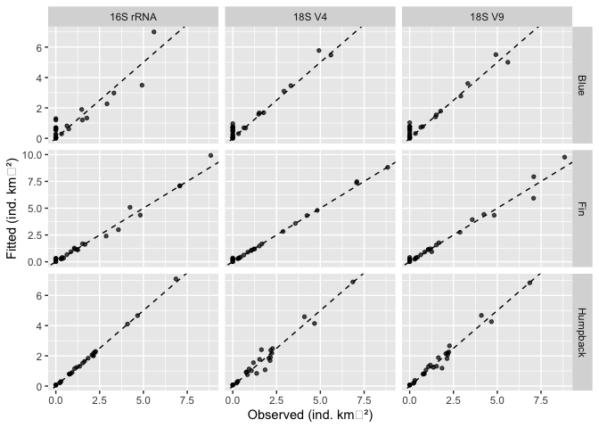

Fitted vs. observed whale density. Dashed line is 1:1.

```r
bind_rows(
  mutate(fit_df_16s,   marker = "16S rRNA"),
  mutate(fit_df_18sv4, marker = "18S V4"),
  mutate(fit_df_18sv9, marker = "18S V9")
) |>
  mutate(species = recode(species, bm = "Blue", bp = "Fin", mn = "Humpback")) |>
  ggplot(aes(x = dens.obs, y = dens.fit)) +
  geom_point(size = 1.2, alpha = 0.7) +
  geom_abline(linetype = "dashed") +
  facet_grid(species ~ marker, scales = "free") +
  labs(x = "Observed (ind. km\u207b\u00b2)", y = "Fitted (ind. km\u207b\u00b2)")
```

## Naive baselines

`naive-preds.R` computes two species-level baselines for comparison: a lag predictor (previous cruise’s density) and a seasonal-mean predictor (mean density for the same calendar quarter). The eDNA RMSPE reported above can be compared against these:

```r
read_rds(here("rslt/models/naive-preds.rds")) |>
  mutate(species = recode(species, bm = "Blue", bp = "Fin", mn = "Humpback")) |>
  rename(Species = species,
         `RMSPE (lag)`           = rmspe.lag,
         `RMSPE (seasonal mean)` = rmspe.mean) |>
  knitr::kable(digits = 4)
```

| Species | RMSPE (lag) | RMSPE (seasonal mean) |
| --- | --- | --- |
| Blue | 1.3590 | 1.2183 |
| Fin | 3.1014 | 2.2885 |
| Humpback | 2.1327 | 1.6680 |

## Figures and tables

`analysis/figures.R` and `analysis/tables.R` produce the manuscript figures and supplementary tables from the fitted model objects and density data. `analysis/data.R` exports any derived data objects used elsewhere. These scripts are the last stage in `run-all.R` and require all upstream results to be present in `rslt/`.